# ML

## Q2:

ما در مسائل ML یک tradeoff بین bias و variance داریم. ما به مدلی که روی داده های Train خوب عمل نمیکنند میگوییم high bias و میگوییم مدل ما بایاس بالایی دارد. و از طرفی هنگامی میگوییم variance مدل ما بالا است که مدل ما بسیار دقیق بر روی داده های Train ما fit شده باشد و خیلی خوب خوب عمل کند اما وقتی مدلمان را میخواهیم ببریم بر روی داده های تست در آنجا خوب عمل نکند و نتیجه ی بدی دهد. پس در کل وقتی bias بالا باشد یعنی عمل آموزش را به خوبی انجام نمیدهیم و underfitting رخ داده است و وقتی که variance بالا باشد مدلمان بر روی Train بسیار خوب fit شده است و اصطلاحا مدل ما پیچیده شده است پس generalization خود را از دست داده است و بر روی Test خوب عمل نمیکند. به این اتفاق overfitting میگوییم. در مدل ما هیچ یک رخ نمیدهد.

# Phase 3

```python
def Random_Forest_E(attributesTrain, answerTrain, attributesTest, answerTtest):
    n_estimators_chart = []
    temp = []
    for i in range(100, 130):
        RF = RandomForestRegressor(n_estimators=i)
        RF.fit(attributesTrain, answerTrain)
        predictions = RF.predict(attributesTest).round()
        n_estimators_chart.append(accuracy_score(answerTtest, predictions))
        temp.append(i)
    plt.plot(temp, n_estimators_chart)
    plt.xlabel('n_estimators')
    plt.ylabel('accuracy')
```

```python
def Random_Forest_M(attributesTrain, answerTrain, attributesTest, answerTtest):
    max_depth_chart = []
    temp = []
    for i in range(100, 130):
        RF = RandomForestRegressor(max_depth=i)
        RF.fit(attributesTrain, answerTrain)
        predictions = RF.predict(attributesTest).round()
        n_estimators_chart.append(accuracy_score(answerTtest, predictions))
        temp.append(i)
    plt.plot(temp, n_estimators_chart)
    plt.xlabel('max_depth')
    plt.ylabel('accuracy')
```

```python
answer = DataFrame["Outcome"].values
attributes = DataFrame.drop(columns=["Outcome"])
attributesTrain, attributesTest, answerTrain, answerTtest = train_test_split(attributes, answer, test_size = 0.2, random_state=48)
```

[figure not shown]

```python
Random_Forest_M(attributesTrain, answerTrain, attributesTest, answerTtest)
```

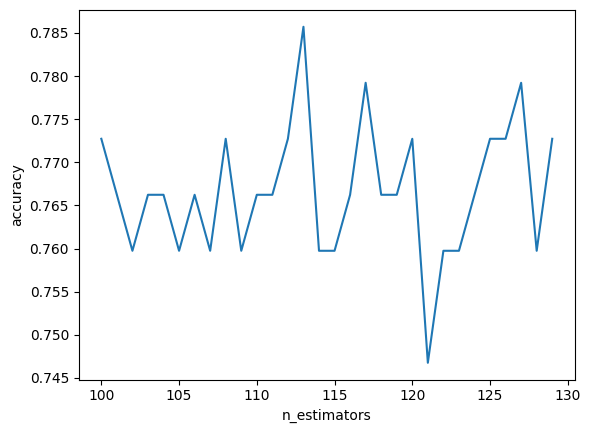

```python
Random_Forest_E(attributesTrain, answerTrain, attributesTest, answerTtest)
```

## Q2:

اگر مدل ما به طور سیستماتیک متغیر هدف را پیش‌بینی کند، می‌گوییم بایاس است. واریانس، به نوعی تعمیم پذیری مدل را نشان می دهد. چیزی که ما می خواهیم، در حالت ایده آل، بایاس کم - واریانس کم است. Random Forest از تعدادی تکنیک برای کاهش واریانس در پیش‌بینی‌ها و در عین حال حفظ واریانس پایین که مشخصه درخت تصمیم تنها بود، استفاده می‌کند. این کار را عمدتاً با میانگین گرفتن تعدادی از درختان با همبستگی بسیار ضعیف انجام می دهد.